# Assignment3: Supervised Learning Competition - Group 11

Authors

Lourenço Santos Moitinho de Almeida

Liam Thomassen

Tim Rentenaar

Erdem Koçer

Published

October 21, 2023

## Data Description & Data Exploration

In order to predict student performance using the various characteristics of the students, we begin our analysis by exploring our dataset. Our exploratory data analysis will roughly follow the guidelines stated by Tukey and Peng. With that said, in order to get a preliminary understanding of our data, we ran the `str()` command as shown below in *Table 1*:

**Table 1:** Checking the Packaging of the Dataset using `str()`

```r
str(train_data)
```

```
tibble [316 × 31] (S3: tbl_df/tbl/data.frame)
 $ school    : Factor w/ 2 levels "GP","MS": 1 1 1 1 1 1 1 1 1 1 ...
 $ sex       : Factor w/ 2 levels "F","M": 1 1 2 2 1 1 2 1 1 2 ...
 $ age       : num [1:316] 18 17 17 18 16 15 15 15 16 15 ...
 $ address   : Factor w/ 2 levels "U","R": 1 1 1 2 1 2 1 1 1 1 ...
 $ famsize   : Factor w/ 2 levels "GT3","LE3": 1 1 1 1 1 2 2 1 1 1 ...
 $ Pstatus   : Factor w/ 2 levels "A","T": 2 2 2 2 2 2 2 2 2 2 ...
 $ Medu      : num [1:316] 3 3 2 4 1 2 3 4 3 2 ...
 $ Fedu      : num [1:316] 2 4 3 3 3 2 3 4 3 3 ...
 $ Mjob      : Factor w/ 5 levels "at_home","health",..: 3 4 3 5 1 2 3 4 3 3 ...
 $ Fjob      : Factor w/ 5 levels "teacher","other",..: 3 2 2 3 3 3 2 5 2 2 ...
 $ reason    : Factor w/ 4 levels "course","other",..: 2 1 1 1 3 4 1 1 3 3 ...
 $ guardian  : Factor w/ 3 levels "mother","father",..: 1 1 2 1 1 1 1 1 1 1 ...
 $ traveltime: num [1:316] 1 1 2 1 1 2 1 1 1 1 ...
 $ studytime : num [1:316] 3 3 1 3 2 2 2 3 3 3 ...
```

[output cut: 17 more lines]

```r
factor_cols <- names(train_data)[sapply(train_data, is.factor)]
num_cols <- names(train_data)[sapply(train_data, is.numeric)]
```

This training dataset contains 316 rows and 31 columns. Furthermore, the column `score` represents our dependent variable while the rest of the columns are explanatory variables. This dataset contains two types of variables: factor (categorial) and numerical variables. Each column can be categorized into one of the two variables types:

- Factor Variables: school, sex, address, famsize, Pstatus, Mjob, Fjob, reason, guardian, schoolsup, famsup, paid, activities, nursery, higher, internet, romantic
- Numerical Variables: age, Medu, Fedu, traveltime, studytime, failures, famrel, freetime, goout, Dalc, Walc, health, absences, score

Additionally, *Figure 1* dispalys that this dataset doesn’t contain any missing values. Therefore, any missing information imputation strategies won’t be required during the data (pre)processing step of our analysis.

**Figure 1:** Counts of all the Missing Data per Column

```r
sapply(train_data, function(x) sum(is.na(x)))
```

```
    school        sex        age    address    famsize    Pstatus       Medu
         0          0          0          0          0          0          0
      Fedu       Mjob       Fjob     reason   guardian traveltime  studytime
         0          0          0          0          0          0          0
  failures  schoolsup     famsup       paid activities    nursery     higher
         0          0          0          0          0          0          0
  internet   romantic     famrel   freetime      goout       Dalc       Walc
         0          0          0          0          0          0          0
    health   absences      score
         0          0          0
```

An important thing to note is that despite the insights given by running the `str()` command, reading the column descriptions file gives contradicting information. For instance out of the 14 numeric columns, only `age`, `absences` and `score` are ‘true’ numericcal variables. The rest of the variables are ordinal variables such as `Dalc`, a variable ranging from 1-5 based on workday alcohol consumption. This assessment is further backed up by analysing the top and bottom of the dataset as shown below in *Table 2* and *Table 3*:

**Table 2:** Top of the Dataset

```r
head(train_data)
```

| school | sex | age | address | famsize | Pstatus | Medu | Fedu | Mjob | Fjob | reason | guardian | traveltime | studytime | failures | schoolsup | famsup | paid | activities | nursery | higher | internet | romantic | famrel | freetime | goout | Dalc | Walc | health | absences | … |
| --- | --- | --- | --- | --- | --- | --- | --- | --- | --- | --- | --- | --- | --- | --- | --- | --- | --- | --- | --- | --- | --- | --- | --- | --- | --- | --- | --- | --- | --- | --- |
| GP | F | 18 | U | GT3 | T | 3 | 2 | other | services | other | mother | 1 | 3 | 0 | no | no | no | no | yes | yes | yes | yes | 5 | 4 | 3 | 2 | 3 | 1 | 7 | … |
| GP | F | 17 | U | GT3 | T | 3 | 4 | services | other | course | mother | 1 | 3 | 0 | no | no | no | no | yes | yes | yes | no | 4 | 4 | 5 | 1 | 3 | 5 | 16 | … |
| GP | M | 17 | U | GT3 | T | 2 | 3 | other | other | course | father | 2 | 1 | 0 | no | no | no | no | yes | yes | yes | no | 5 | 2 | 2 | 1 | 1 | 2 | 4 | … |
| GP | M | 18 | R | GT3 | T | 4 | 3 | teacher | services | course | mother | 1 | 3 | 0 | no | no | no | no | yes | yes | yes | yes | 5 | 3 | 2 | 1 | 2 | 4 | 9 | … |
| GP | F | 16 | U | GT3 | T | 1 | 3 | at_home | services | home | mother | 1 | 2 | 3 | no | no | no | yes | no | yes | yes | yes | 4 | 3 | 5 | 1 | 1 | 3 | 0 | … |
| GP | F | 15 | R | LE3 | T | 2 | 2 | health | services | reputation | mother | 2 | 2 | 0 | yes | yes | yes | no | yes | yes | yes | no | 4 | 1 | 3 | 1 | 3 | 4 | 2 | … |

**Table 3:** Bottom of the Dataset

```r
tail(train_data)
```

| school | sex | age | address | famsize | Pstatus | Medu | Fedu | Mjob | Fjob | reason | guardian | traveltime | studytime | failures | schoolsup | famsup | paid | activities | nursery | higher | internet | romantic | famrel | freetime | goout | Dalc | Walc | health | absences | … |
| --- | --- | --- | --- | --- | --- | --- | --- | --- | --- | --- | --- | --- | --- | --- | --- | --- | --- | --- | --- | --- | --- | --- | --- | --- | --- | --- | --- | --- | --- | --- |
| GP | F | 17 | U | GT3 | T | 4 | 2 | other | other | reputation | mother | 2 | 3 | 0 | no | yes | yes | no | yes | yes | yes | no | 4 | 3 | 3 | 1 | 1 | 3 | 0 | … |
| GP | M | 15 | R | GT3 | T | 4 | 3 | teacher | at_home | course | mother | 1 | 2 | 0 | no | yes | no | yes | yes | yes | yes | yes | 4 | 5 | 2 | 1 | 1 | 5 | 0 | … |
| GP | M | 17 | U | LE3 | T | 4 | 4 | other | teacher | home | father | 2 | 1 | 0 | no | no | yes | no | yes | yes | yes | no | 4 | 1 | 1 | 2 | 2 | 5 | 0 | … |
| GP | M | 16 | U | GT3 | T | 4 | 4 | services | services | other | mother | 1 | 1 | 0 | yes | yes | yes | yes | yes | yes | yes | no | 4 | 5 | 5 | 5 | 5 | 4 | 14 | … |
| MS | F | 17 | R | GT3 | T | 3 | 1 | at_home | other | reputation | mother | 1 | 2 | 0 | no | yes | yes | yes | no | yes | yes | no | 4 | 5 | 4 | 2 | 3 | 1 | 17 | … |
| GP | F | 15 | U | GT3 | T | 4 | 4 | teacher | health | reputation | mother | 1 | 2 | 0 | no | yes | yes | no | yes | yes | yes | no | 3 | 3 | 3 | 1 | 2 | 2 | 0 | … |

### The Analysis for the Dependent Variable: Score

```r
minimum_value <- round(min(train_data$score), 2)
maximum_value <- round(max(train_data$score), 2)
median_value <- round(median(train_data$score), 2)
q1_value <- round(quantile(train_data$score, 0.25), 2)
q3_value <- round(quantile(train_data$score, 0.75), 2)
```

The whole aim of this analysis is to predict scores for students in the test dataset. In order to do so we took a closer look at the variable `score`. Below, *Figure 2* displays the spread of `score` in addition to a 5-number summary. Following the inter-quartile range rule for outlier detection, scores outside the range of $-2.535\leq x \leq 2.545$ would be considered outliers.

**Figure 2:** The Spread and 5-Number Summary of `score`

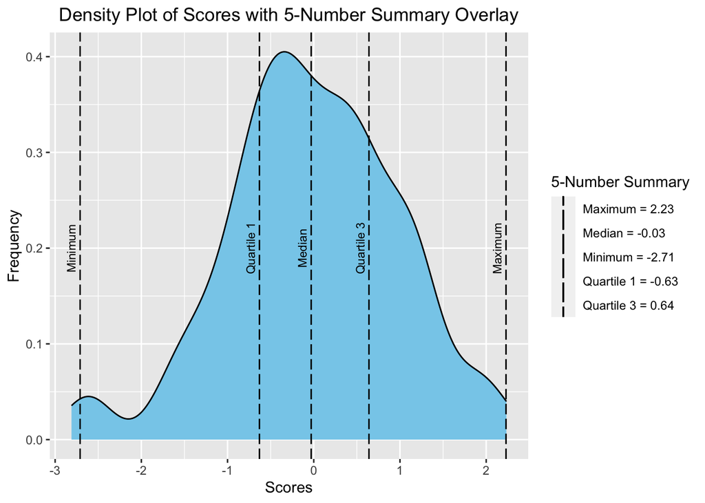

```r
ggplot(train_data, aes(x = score)) +
  geom_density(fill = "skyblue") +
  xlab("Scores") +
  ylab("Frequency") +
  ggtitle("Density Plot of Scores with 5-Number Summary Overlay") +
  theme(plot.title = element_text(hjust = 0.5)) +

  geom_vline(aes(xintercept = minimum_value, color = "Minimum = -2.71"), linetype = "longdash") +
  annotate(geom = "text", label = "Minimum", color = "black", angle = 90, x = minimum_value-0.1, y = 0.2, size = 3) +

  geom_vline(aes(xintercept = maximum_value, color = "Maximum = 2.23"), linetype = "longdash") +
  annotate(geom = "text", label = "Maximum", color = "black", angle = 90, x = maximum_value-0.1, y = 0.2, size = 3) +

  geom_vline(aes(xintercept = median_value, color = "Median = -0.03"), linetype = "longdash") +
  annotate(geom = "text", label = "Median", color = "black", angle = 90, x = median_value-0.1, y = 0.2, size = 3) +

  geom_vline(aes(xintercept = q1_value, color = "Quartile 1 = -0.63"), linetype = "longdash") +
  annotate(geom = "text", label = "Quartile 1", color = "black", angle = 90, x = q1_value-0.1, y = 0.2, size = 3) +

  geom_vline(aes(xintercept = q3_value, color = "Quartile 3 = 0.64"), linetype = "longdash") +
  annotate(geom = "text", label = "Quartile 3", color = "black", angle = 90, x = q3_value-0.1, y = 0.2, size = 3) +

  scale_color_manual("5-Number Summary", values = c("Minimum = -2.71" = "black", "Maximum = 2.23" = "black", "Median = -0.03" = "black", "Quartile 1 = -0.63" = "black", "Quartile 3 = 0.64" = "black"))
```

### Correlation between Score and the Explanatory Variables

For the correlation between `score` and the rest of the explanatory variables we divided the training dataset by variable type. *Table 4* displays the correlation between the numerical variables. The variables `failures`, `goout` and `age` measuring the student’s number of past class failures, time spent with friend and age seemed to have the greatest negative correlation against `score` while `Medu` and `Fedu`, variables measuring their parent’s education seemed to have the greatest positive correlation. Additionally, `goout` and `Dalc` (workday alcohol consumption) are both positively correlated with `Walc` (weekend alcohol consumption). In contrast, *Table 5* displays the correlation between the converted dummy categorical variables and `score`. Although, none of the categorical variables seemed to be correlated with `score`. The only strongly correlated variables in this table were between the categories of `Mjob` and `Fjob` (variables that measure the parent’s occupation).

**Note:** Do we remove the correlated variables for the analysis and models?

**Table 4:** Correlation Matrix between Numerical Variables and `score`

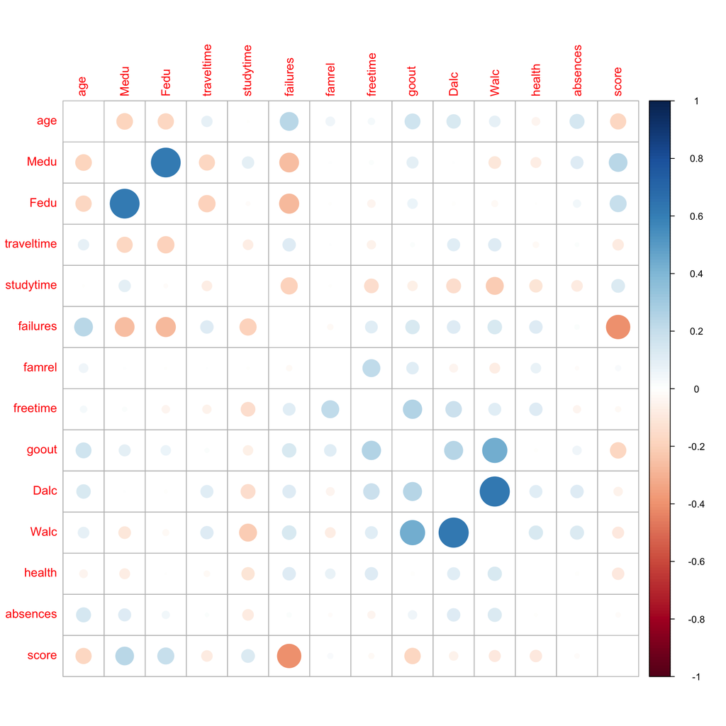

```r
corrplot(cor(train_data[sapply(train_data, is.numeric)]), diag = FALSE)
```

**Table 5:** Correlation Matrix between Converted Categorical Variables and `score`

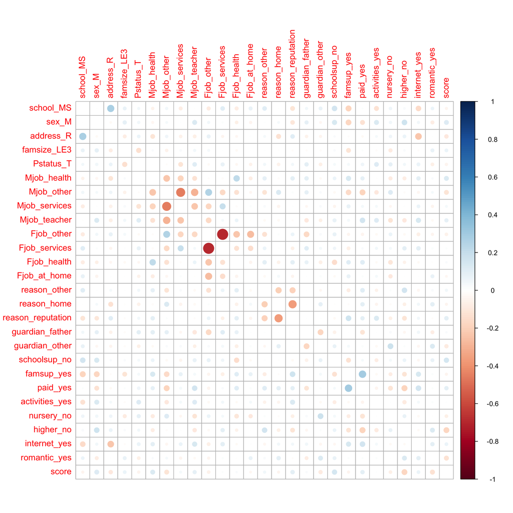

```r
temp_df <- train_data[, !sapply(train_data, is.numeric)]
temp_df_dummy <- dummy_cols(temp_df,remove_first_dummy=TRUE,remove_selected_columns=TRUE)
temp_df_dummy$score <- train_data$score

corrplot(cor(temp_df_dummy), diag = FALSE)
```

## Data Preparation

### Data Cleaning

We have taken no data cleaning measures

### Data Transformation

We have taken a single tranformation measure, which is dummy coding the categorical attributes

```r
# dummy coding
train_dummy <- dummy_cols(train_data, remove_selected_columns = TRUE)
test_dummy <- dummy_cols(test_data, remove_selected_columns = TRUE)
```

### Data reduction

We have taken no data reduction measures

## Model Training

### Creating Train/dev splits

Single train/dev split

```r
# creating a single train/dev split with a random 80/20 split
sample_size <- floor(0.8 * nrow(train_dummy))

set.seed(1)
train_index <- sample(seq_len(nrow(train_dummy)), size=sample_size)

train_dummy_train <- train_dummy[train_index,]
train_dummy_dev <- train_dummy[-train_index,]
```

k-fold cross validation

```r
# k-fold cross validation, k=5
train_control <- trainControl(method="cv", number=5)
```

### Training different models

#### Trivial baseline (mean)

We have chosen to create a trivial baseline by taking the mean score of the train data as the score for the dev data. So we are able to evaluate if our models perform better than this baseline.

```r
# creating a mean trivial baseline is not possible with the caret package
# the mean trivial baseline will be created with a single train/dev split

mean_score_train <- mean(train_dummy_train$score)
```

#### Linear regression

Another model we consider is the linear regression model, which we have applied to our k-fold cross validation.

```r
# training a linear model using k-fold crossvalidation
lm <- train(score ~ ., data=train_dummy, method="lm", trControl=train_control)
```

#### Neural Network

Another model we consider is the neural network model, which we have applied to our k-fold cross validation.

```r
# training a model averaged neural network using k-fold crossvalidation
nn <- train(score ~ ., data=train_dummy, method="avNNet", trControl=train_control)
```

[output not shown]

[output cut: 394 more lines]

[output not shown]

[output not shown]

#### kNN

Another model we consider is the k Nearest Neighbours model, which we have applied to our k-fold cross validation.

```r
# training knn using k-fold crossvalidation
knn <- train(score ~ ., data=train_dummy, method="knn", trControl=train_control)
```

# Model Exploration

## Cross Validation

#### Trivial baseline (mean)

The trivial baseline is evaluated by calculating the MAE and the MSE

```r
# resulting MAE and MSE from the trivial baseline
mae <- mean(abs(train_dummy_dev$score - mean_score_train))
mse <- mean((train_dummy_dev$score - mean_score_train) ** 2)

print(mae)
```

```
[1] 0.7483624
```

```r
print(mse)
```

```
[1] 0.8831195
```

#### Linear Regression

The linear regression model is evaluated with RMSE, Rsquared, and MAE

```r
# resulting scores (including MAE) from linear regression
print(lm)
```

```
Linear Regression

316 samples
 56 predictor

No pre-processing
Resampling: Cross-Validated (5 fold)
Summary of sample sizes: 253, 252, 253, 253, 253
Resampling results:

  RMSE       Rsquared   MAE
  0.9415091  0.1436198  0.7473462

Tuning parameter 'intercept' was held constant at a value of TRUE
```

#### Neural Network

The neural network model is evaluated with RMSE, Rsquared, and MAE

```r
print(nn)
```

```
Model Averaged Neural Network

316 samples
 56 predictor

No pre-processing
Resampling: Cross-Validated (5 fold)
Summary of sample sizes: 253, 252, 252, 254, 253
Resampling results across tuning parameters:

  size  decay  RMSE       Rsquared    MAE
  1     0e+00  0.9842995         NaN  0.7840139
  1     1e-04  0.9747400  0.04431437  0.7763265
  1     1e-01  0.9564550  0.16322956  0.7488211
  3     0e+00  0.9842995         NaN  0.7840139
  3     1e-04  0.9612688  0.10098795  0.7595723
  3     1e-01  0.9623769  0.13624933  0.7565165
  5     0e+00  0.9842995         NaN  0.7840139
  5     1e-04  0.9679523  0.09475522  0.7521365
  5     1e-01  0.9661836  0.13006100  0.7577878

Tuning parameter 'bag' was held constant at a value of FALSE
RMSE was used to select the optimal model using the smallest value.
The final values used for the model were size = 1, decay = 0.1 and bag = FALSE.
```

#### kNN

The kNN model is evaluated with RMSE, Rsquared, and MAE

```r
print(knn)
```

```
k-Nearest Neighbors

316 samples
 56 predictor

No pre-processing
Resampling: Cross-Validated (5 fold)
Summary of sample sizes: 253, 254, 252, 253, 252
Resampling results across tuning parameters:

  k  RMSE       Rsquared   MAE
  5  0.9540641  0.1091454  0.7324686
  7  0.9322787  0.1342290  0.7209982
  9  0.9226446  0.1392831  0.7200559

RMSE was used to select the optimal model using the smallest value.
The final value used for the model was k = 9.
```

According to the cross validation results, the best-performing model was kNN. However, these are quick calculations to see what kind of models would work for this problem. That is, by tuning the hyperparameters of more complex models such as neural networks or tree-based algorithms, better score on train set can be achieved.

## Models

Split feature vectors

```r
X_train <- train_dummy_train[, -which(names(train_dummy_train) == "score")]
y_train <- data.frame(train_dummy_train$score)
X_test <- train_dummy_dev[, -which(names(train_dummy_dev) == "score")]
y_test <- train_dummy_dev$score
```

### Bayesian Regression

```r
combined_prior <- prior(
  normal(0, 0.6),
  class = "b"
)

model <- brm(score ~.,data = train_dummy_train, chains = 4, iter = 8000, prior = combined_prior)
```

```
Trying to compile a simple C file
```

[output not shown]

```r
# View the model summary
summary(model)
```

```
 Family: gaussian
  Links: mu = identity; sigma = identity
Formula: score ~ age + Medu + Fedu + traveltime + studytime + failures + famrel + freetime + goout + Dalc + Walc + health + absences + school_GP + school_MS + sex_F + sex_M + address_U + address_R + famsize_GT3 + famsize_LE3 + Pstatus_A + Pstatus_T + Mjob_at_home + Mjob_health + Mjob_other + Mjob_se…
   Data: train_dummy_train (Number of observations: 252)
  Draws: 4 chains, each with iter = 8000; warmup = 4000; thin = 1;
         total post-warmup draws = 16000

Population-Level Effects:
                  Estimate Est.Error l-95% CI u-95% CI Rhat Bulk_ESS Tail_ESS
Intercept             1.64      2.02    -2.33     5.57 1.00    17033    11944
age                  -0.13      0.06    -0.26    -0.01 1.00    22920    11972
Medu                  0.09      0.08    -0.07     0.25 1.00    20051    13049
Fedu                  0.06      0.07    -0.09     0.21 1.00    20864    13864
traveltime            0.05      0.09    -0.13     0.22 1.00    22471    13202
studytime             0.15      0.07    -0.00     0.29 1.00    24257    12770
failures             -0.42      0.09    -0.60    -0.25 1.00    24300    12898
famrel                0.00      0.07    -0.13     0.14 1.00    25624    12275
freetime              0.07      0.06    -0.06     0.20 1.00    22783    12306
goout                -0.15      0.06    -0.27    -0.02 1.00    20565    13379
Dalc                  0.03      0.09    -0.15     0.20 1.00    20540    12599
Walc                 -0.00      0.07    -0.13     0.13 1.00    18060    13428
health               -0.04      0.05    -0.13     0.05 1.00    25537    12733
absences              0.01      0.01    -0.01     0.02 1.00    25552    12434
school_GP            -0.01      0.43    -0.86     0.84 1.00    17005    12768
school_MS             0.02      0.43    -0.83     0.88 1.00    16671    12638
sex_F                -0.18      0.43    -1.01     0.65 1.00    17643    12059
sex_M                 0.18      0.43    -0.65     1.01 1.00    17533    11926
address_U             0.05      0.43    -0.81     0.89 1.00    16638    12504
address_R            -0.05      0.43    -0.91     0.79 1.00    16454    12357
famsize_GT3          -0.06      0.43    -0.90     0.79 1.00    15884    11370
famsize_LE3           0.05      0.43    -0.79     0.90 1.00    16251    11841
Pstatus_A            -0.05      0.43    -0.91     0.80 1.00    15366    12803
Pstatus_T             0.06      0.44    -0.80     0.90 1.00    15685    12090
Mjob_at_home          0.10      0.31    -0.51     0.70 1.00     9755    11498
Mjob_health           0.26      0.31    -0.36     0.87 1.00    10567    12616
Mjob_other           -0.12      0.29    -0.69     0.45 1.00     9055    10168
Mjob_services         0.09      0.29    -0.48     0.66 1.00     8721     9556
Mjob_teacher         -0.31      0.31    -0.91     0.31 1.00    10002    11721
Fjob_teacher          0.15      0.33    -0.50     0.79 1.00    11543    12645
Fjob_other           -0.16      0.29    -0.73     0.41 1.00     9986    10996
```

[output cut: 19 more lines]

```
nursery_no            0.01      0.43    -0.83     0.85 1.00    17327    12352
higher_yes            0.17      0.45    -0.70     1.03 1.00    18494    12859
higher_no            -0.16      0.45    -1.04     0.71 1.00    18814    12860
internet_no          -0.03      0.43    -0.88     0.81 1.00    16317    12744
internet_yes          0.02      0.43    -0.82     0.88 1.00    16379    12644
romantic_no           0.10      0.42    -0.73     0.93 1.00    16226    12391
romantic_yes         -0.11      0.42    -0.94     0.72 1.00    15948    11917

Family Specific Parameters:
      Estimate Est.Error l-95% CI u-95% CI Rhat Bulk_ESS Tail_ESS
sigma     0.87      0.04     0.79     0.96 1.00    17505    11328

Draws were sampled using sampling(NUTS). For each parameter, Bulk_ESS
and Tail_ESS are effective sample size measures, and Rhat is the potential
scale reduction factor on split chains (at convergence, Rhat = 1).
```

### Bayesian Model Evaluation

```r
pred_y_bayesian <- predict(model,newdata = train_dummy_dev)
pred_y_bayesian<-data.frame(pred_y_bayesian)
pred_y_bayesian<- pred_y_bayesian$Estimate
cat("mse of bayesian model: ", mean((as.matrix(pred_y_bayesian)-as.matrix(y_test))^2))
```

```
mse of bayesian model:  0.8472409
```

### XGBoost

```r
xgb_train = xgb.DMatrix(data = as.matrix(X_train), label = as.matrix(y_train))
xgb_test = xgb.DMatrix(data = as.matrix(X_test), label = as.matrix(y_test))

watchlist = list(train=xgb_train, test=xgb_test)
xgb_model = xgb.train(data = xgb_train, max.depth = 3, watchlist=watchlist, nrounds = 10,verbose=1)
```

### XGBoost Model Evaluation

```r
model_xgboost = xgboost(data = xgb_train, max.depth = 3, nrounds = 5, verbose = 0)
pred_y_xgboost <- predict(model_xgboost,xgb_test)

cat("mse of xgboost model: ", mean((as.matrix(pred_y_xgboost)-as.matrix(y_test))^2))
```

```
mse of xgboost model:  0.6961323
```

### Lasso Regression

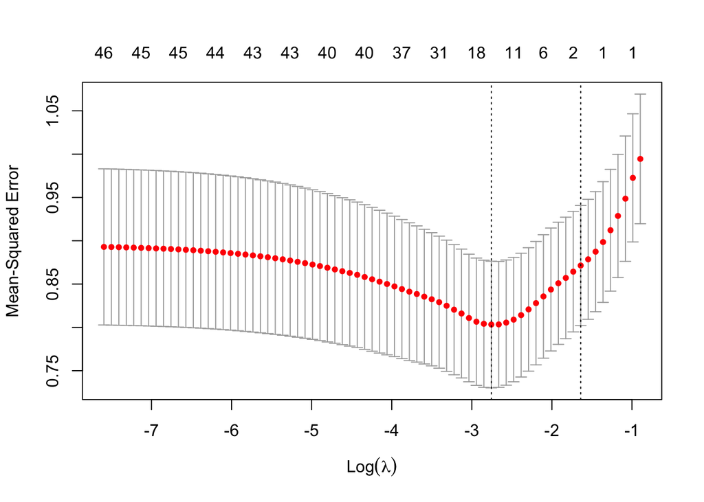

```r
original_weights <- rep(1, nrow(X_train))

cv_model <- cv.glmnet(data.matrix(X_train), data.matrix(y_train), alpha = 1)

best_lambda <- cv_model$lambda.min
best_model <- glmnet(data.matrix(X_train), data.matrix(y_train), alpha = 1, lambda = best_lambda)
plot(cv_model)
```

### Lasso Model Evaluation

```r
pred_y_lasso <- predict(best_model, s = best_lambda, newx = data.matrix(X_test))
cat("mse of lasso model: ", mean((as.matrix(pred_y_lasso)-as.matrix(y_test))^2))
```

```
mse of lasso model:  0.7161947
```

### Support Vector Machine

```r
svm_model <- svm(x = X_train, y = y_train, kernel = "radial", cost = 1)
pred_y_svm <- predict(svm_model, newdata = X_test)
cat("mse of SVM model: ", mean((as.matrix(pred_y_svm)-as.matrix(y_test))^2))
```

```
mse of SVM model:  0.7826527
```

### GAM

```r
gam_model <- gam(score ~ s(age,k=3) +
                   s(failures, k=4) +
                   s(studytime, k = 4) +
                   internet_no +
                   sex_M +
                   famsize_GT3 +
                   Dalc +
                   Walc +
                   Pstatus_A +
                   reason_reputation,
                 data = train_dummy_train)

testing_data <- data.frame(X_test)

pred_y_gam <- predict(gam_model, newdata = testing_data)
cat("mse of GAM model: ", mean((as.matrix(pred_y_gam)-as.matrix(y_test))^2))
```

```
mse of GAM model:  0.7236812
```

### Neural Networks

#### Simple Neural Network

```r
library(tensorflow)
library(keras)

model <- keras_model_sequential() %>%
    layer_dense(16, activation = 'relu') %>%
    layer_dropout(0.1) %>%
    layer_dense(8, activation = 'relu') %>%
    layer_dropout(0.1) %>%
    layer_dense(1)

model %>% compile(
  loss = 'mean_absolute_error',
  optimizer = optimizer_adam()
)

plot_model <- model %>% fit(as.matrix(X_train),
      as.matrix(y_train),
      epochs = 100,
      validation_split = 0.1,
      verbose = 0)

pred_y_nn <- predict(model, as.matrix(X_test))
```

```
2/2 - 0s - 88ms/epoch - 44ms/step
```

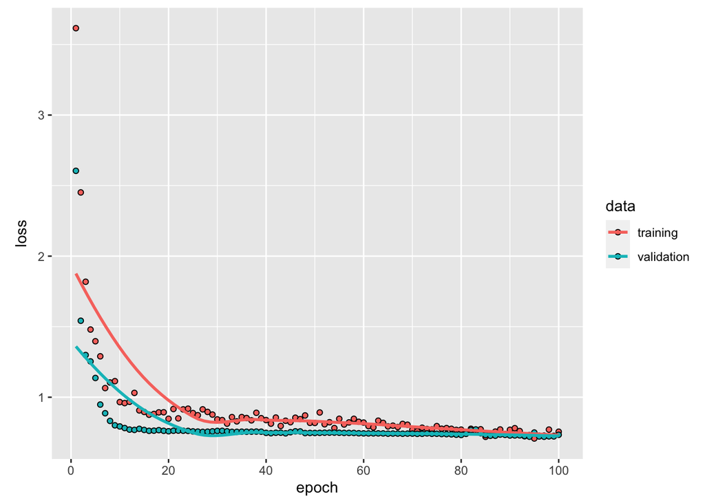

```r
plot(plot_model)
```

#### Simple Neural Network Evaluation

```r
cat("mse of simple NN model: ", mean((as.matrix(pred_y_nn)-as.matrix(y_test))^2))
```

```
mse of simple NN model:  0.7831245
```

### Complex Neural Network

```r
model_complex <- keras_model_sequential() %>%
    layer_dense(512, activation = 'relu', regularizer_l1_l2(l1=0.01,l2=0.01)) %>%
    layer_dropout(0.2) %>%
    layer_dense(128, activation = 'relu', regularizer_l1_l2(l1=0.01,l2=0.01)) %>%
    layer_dropout(0.2) %>%
    layer_dense(64, activation = 'relu', regularizer_l1_l2(l1=0.01,l2=0.01)) %>%
    layer_dropout(0.2) %>%
    layer_dense(32, activation = 'relu', regularizer_l1_l2(l1=0.01,l2=0.01)) %>%
    layer_dropout(0.2) %>%
    layer_dense(16, activation = 'relu', regularizer_l1_l2(l1=0.01,l2=0.01)) %>%
    layer_dropout(0.2) %>%
    layer_dense(8, activation = 'relu') %>%
    layer_dense(1)

model_complex %>% compile(
  loss = 'mean_absolute_error',
  optimizer = optimizer_adam()
)

plot_model <- model_complex %>% fit(as.matrix(X_train),
      as.matrix(y_train),
      epochs = 85,
      validation_split = 0.1,
      verbose = 0)

pred_y_nn_complex <- predict(model_complex, as.matrix(X_test))
```

```
2/2 - 0s - 89ms/epoch - 44ms/step
```

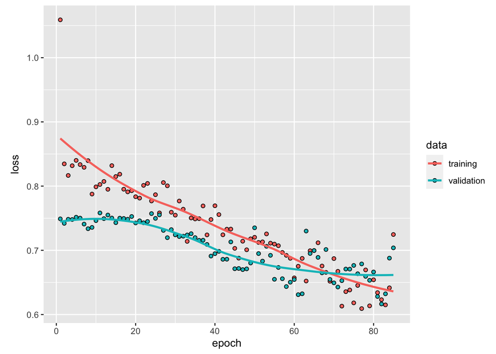

```r
plot(plot_model)
```

#### Complex Neural Network Evaluation

```r
cat("mse of simple NN model: ", mean((as.matrix(pred_y_nn_complex)-as.matrix(y_test))^2))
```

```
mse of simple NN model:  0.7598974
```

### Ensemble Models

Instead of selecting one model, multiple models can be combined

```r
# Combine Complex NN with XGBoost
combined_model <- (pred_y_xgboost + pred_y_lasso) / 2

cat("mse of combined model: ", mean((as.matrix(combined_model)-as.matrix(y_test))^2))
```

```
mse of combined model:  0.684058
```

#### Chosen Model

*Current best is ensemble of multiple models*

## Result

*Apply the chosen model to predict the scores for the test data and export the result*

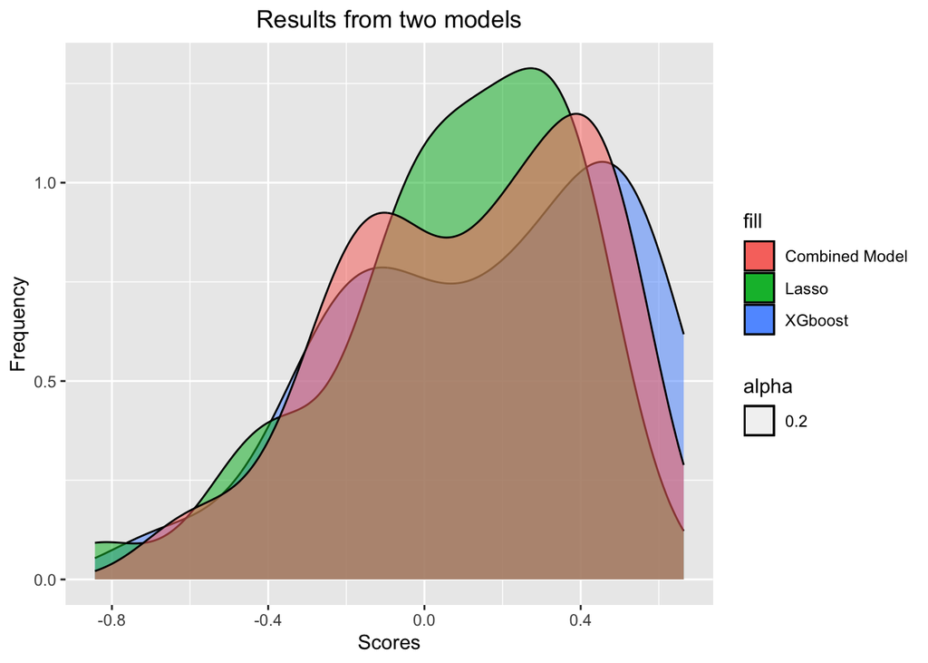

```r
xgb_test_Data <- xgb.DMatrix(data = as.matrix(test_dummy))
pred_real_y_xgboost <- predict(model_xgboost, xgb_test_Data)

pred_real_y_lasso <- predict(best_model, s = best_lambda, newx = data.matrix(test_dummy))

combined_real_model <- (pred_real_y_lasso + pred_real_y_xgboost) / 2

new_frame <- data.frame(pred_real_y_xgboost,pred_real_y_lasso,combined_real_model)

ggplot(data = new_frame) +
  geom_density(aes(pred_real_y_xgboost, fill = "XGboost", alpha=0.2)) +
  geom_density(aes(s1, fill = "Lasso", alpha=0.2)) +
  geom_density(aes(s1.1, fill = "Combined Model", alpha=0.2)) +
  xlab("Scores") +
  ylab("Frequency") +
  ggtitle("Results from two models") +
  theme(plot.title = element_text(hjust = 0.5))
```

### Save the file

```r
saveRDS(combined_real_model, "predictions.rds")
```